# Data 607 Project_2

2019-03-10

# Preparing different datasets for downstream analysis work

## loading the required packages

```r
# install.packages('tidyr') install.packages('dplyr')
library(tidyr)
library(dplyr)
```

# Dataset of relation between income and religion in US experiment

## Create a dataframe and load the dataset from the .csv file

This dataset explores the relationship between income and religion in the US. It comes from a report produced by the Pew Research Center, an American think-tank that collects data on attitudes to topics ranging from religion to the internet, and produces many reports that contain datasets in this format.

```
# A tibble: 18 x 11
   religion `<$10k` `$10-20k` `$20-30k` `$30-40k` `$40-50k` `$50-75k`
   <chr>      <int>     <int>     <int>     <int>     <int>     <int>
 1 Agnostic      27        34        60        81        76       137
 2 Atheist       12        27        37        52        35        70
 3 Buddhist      27        21        30        34        33        58
 4 Catholic     418       617       732       670       638      1116
 5 Don’t k…      15        14        15        11        10        35
 6 Evangel…     575       869      1064       982       881      1486
 7 Hindu          1         9         7         9        11        34
 8 Histori…     228       244       236       238       197       223
 9 Jehovah…      20        27        24        24        21        30
10 Jewish        19        19        25        25        30        95
11 Mainlin…     289       495       619       655       651      1107
12 Mormon        29        40        48        51        56       112
13 Muslim         6         7         9        10         9        23
14 Orthodox      13        17        23        32        32        47
15 Other C…       9         7        11        13        13        14
16 Other F…      20        33        40        46        49        63
17 Other W…       5         2         3         4         2         7
18 Unaffil…     217       299       374       365       341       528
# … with 4 more variables: `$75-100k` <int>, `$100-150k` <int>,
#   `>150k` <int>, `Don't know/refused` <int>
```

## Tidying and Transforming Data

This dataset has three variables, religion, income and frequency. To tidy it, we need to gather the non-variable columns into a two-column key-value pair. This action is often described as making a wide dataset long (or tall), but I’ll avoid those terms because they’re imprecise.

When gathering variables, we need to provide the name of the new key-value columns to create. The first argument, is the name of the key column, which is the name of the variable defined by the values of the column headings. In this case, it’s income. The second argument is the name of the value column, frequency. The third argument defines the columns to gather, here, every column except religion.

```
# A tibble: 180 x 3
   religion                income frequency
   <chr>                   <chr>      <int>
 1 Agnostic                <$10k         27
 2 Atheist                 <$10k         12
 3 Buddhist                <$10k         27
 4 Catholic                <$10k        418
 5 Don’t know/refused      <$10k         15
 6 Evangelical Prot        <$10k        575
 7 Hindu                   <$10k          1
 8 Historically Black Prot <$10k        228
 9 Jehovah's Witness       <$10k         20
10 Jewish                  <$10k         19
# … with 170 more rows
```

This form is tidy because each column represents a variable and each row represents an observation, in this case a demographic unit corresponding to a combination of religion and income.

Plot a graph between income and frequency which is grouped by religion

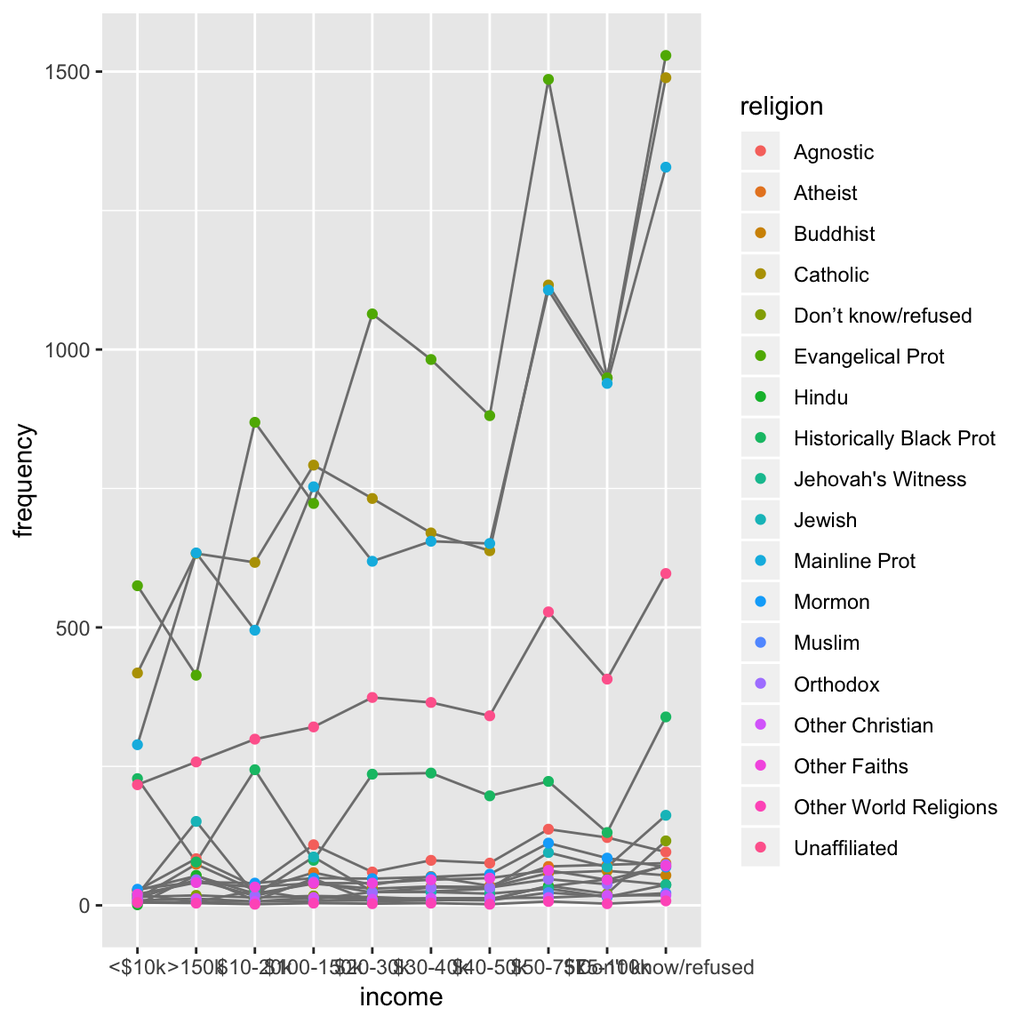

In graph we see, the highest no. of people which has a salary range below 10k $ belong to evangelical prot

And the highest no. of people which has a salary range between >150k $ belong to Mainline Prot followed by catholic group.

Calculate the mean for the number of people in each religion group using the aggregate function. There are total 18 groups of religion.

```
                  religion frequency
1                 Agnostic      82.6
2                  Atheist      51.5
3                 Buddhist      41.1
4                 Catholic     805.4
5       Don’t know/refused      27.2
6         Evangelical Prot     947.2
7                    Hindu      25.7
8  Historically Black Prot     199.5
9        Jehovah's Witness      21.5
10                  Jewish      68.2
11           Mainline Prot     747.0
12                  Mormon      58.1
13                  Muslim      11.6
14                Orthodox      36.3
15         Other Christian      12.9
16            Other Faiths      44.9
17   Other World Religions       4.2
18            Unaffiliated     370.7
```

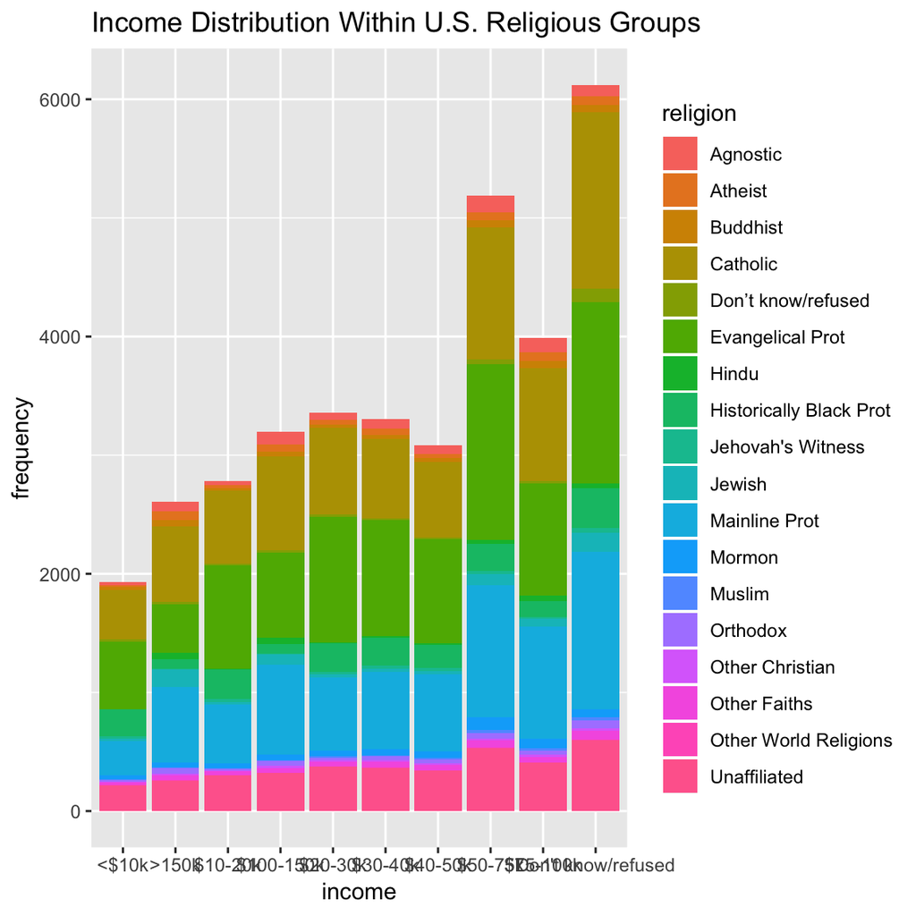

## Conclusion

From the graph we can see that religious tradition clearly varies by income level. We can see that for the highest income category (>$150k), ‘Mainline Prot’ followed by ‘ Catholic’ have the highest proportions. If we examine the lowest income category (<$10k) we see that ‘Evangelical Prot’ have the highest proportions

# Dataset of Engilsh Premier League

## Create a dataframe and load the dataset from the .csv file

```
# A tibble: 20 x 20
   Team       P     W     D     L    GF    GA    GD   Pts   PPG    Wh    Dh
   <chr>  <int> <int> <int> <int> <int> <int> <int> <int> <dbl> <int> <int>
 1 Manch…     7     6     0     1    18     7    11    18 2.57      3     0
 2 Totte…     7     5     2     0    12     3     9    17 2.43      3     1
 3 Arsen…     7     5     1     1    16     7     9    16 2.29      2     0
 4 Liver…     7     5     1     1    18    10     8    16 2.29      2     0
 5 Evert…     7     4     2     1    11     5     6    14 2         2     2
 6 Manch…     7     4     1     2    13     8     5    13 1.86      2     1
 7 Chels…     7     4     1     2    12     9     3    13 1.86      2     0
 8 Cryst…     7     3     2     2    11     8     3    11 1.57      1     1
 9 West …     7     2     3     2     8     7     1     9 1.29      1     1
10 South…     7     2     3     2     7     6     1     9 1.29      1     2
11 Watfo…     7     2     2     3    12    13    -1     8 1.14      1     1
12 Leice…     7     2     2     3     8    11    -3     8 1.14      2     2
13 Bourn…     7     2     2     3     6    11    -5     8 1.14      2     0
14 Burnl…     7     2     1     4     5     9    -4     7 1         2     1
15 Hull …     7     2     1     4     7    14    -7     7 1         1     0
16 Middl…     7     1     3     3     7    10    -3     6 0.86      0     1
17 Swans…     7     1     1     5     6    12    -6     4 0.570     0     1
18 West …     7     1     1     5     8    17    -9     4 0.570     1     1
19 Stoke…     7     0     3     4     5    16   -11     3 0.43      0     1
20 Sunde…     7     0     2     5     6    13    -7     2 0.290     0     1
# … with 8 more variables: Lh <int>, GFh <int>, GAh <int>, Wa <int>,
#   Da <int>, La <int>, GFa <int>, Gaa <int>
```

## Tidying and Transforming Data

```
'data.frame':   20 obs. of  20 variables:
 $ Team: chr  "Manchester City" "Tottenham" "Arsenal" "Liverpool" ...
 $ P   : int  7 7 7 7 7 7 7 7 7 7 ...
 $ W   : int  6 5 5 5 4 4 4 3 2 2 ...
 $ D   : int  0 2 1 1 2 1 1 2 3 3 ...
 $ L   : int  1 0 1 1 1 2 2 2 2 2 ...
 $ GF  : int  18 12 16 18 11 13 12 11 8 7 ...
 $ GA  : int  7 3 7 10 5 8 9 8 7 6 ...
 $ GD  : int  11 9 9 8 6 5 3 3 1 1 ...
 $ Pts : int  18 17 16 16 14 13 13 11 9 9 ...
 $ PPG : num  2.57 2.43 2.29 2.29 2 1.86 1.86 1.57 1.29 1.29 ...
 $ Wh  : int  3 3 2 2 2 2 2 1 1 1 ...
 $ Dh  : int  0 1 0 0 2 1 0 1 1 2 ...
 $ Lh  : int  0 0 1 0 0 1 1 1 1 0 ...
 $ GFh : int  9 5 8 9 6 8 6 5 5 3 ...
 $ GAh : int  2 1 5 2 3 4 3 3 4 2 ...
 $ Wa  : int  3 2 3 3 2 2 2 1 1 1 ...
 $ Da  : int  0 1 1 1 0 0 1 2 2 1 ...
 $ La  : int  1 0 0 1 1 1 1 1 1 2 ...
 $ GFa : int  9 7 8 9 5 5 6 6 3 4 ...
 $ Gaa : int  5 2 2 8 2 4 6 5 3 4 ...
```

```
 [1] "Team" "P"    "W"    "D"    "L"    "GF"   "GA"   "GD"   "Pts"  "PPG"
[11] "Wh"   "Dh"   "Lh"   "GFh"  "GAh"  "Wa"   "Da"   "La"   "GFa"  "Gaa"
```

Using the functions provided by tidyr and dplyr packages

Select the appropriate columns that are needed. Then calculate the total goals by adding total_goals_scored_home and total_goals_scored_away And also calculating Total_goals_conceded_home by adding goals_conceded_at_home and goals_conceded_away

rename those columns for a meaningful look

```
# A tibble: 20 x 10
   team  total_goals_sco… total_goals_sco…   Pts goals_scored_at…
   <chr>            <int>            <int> <int>            <int>
 1 Manc…               18                7    18                9
 2 Tott…               12                3    17                5
 3 Arse…               16                7    16                8
 4 Live…               18               10    16                9
 5 Ever…               11                5    14                6
 6 Manc…               13                8    13                8
 7 Chel…               12                9    13                6
 8 Crys…               11                8    11                5
 9 West…                8                7     9                5
10 Sout…                7                6     9                3
11 Watf…               12               13     8                7
12 Leic…                8               11     8                5
13 Bour…                6               11     8                3
14 Burn…                5                9     7                5
15 Hull…                7               14     7                3
16 Midd…                7               10     6                3
17 Swan…                6               12     4                4
18 West…                8               17     4                4
19 Stok…                5               16     3                2
20 Sund…                6               13     2                4
# … with 5 more variables: goals_conceded_at_home <int>,
#   goals_scored_away <int>, goals_conceded_away <int>, Total_goals <int>,
#   Total_goals_conceded_home <int>
```

According to the chart found on www.soccerstats.com, home advantage should show the following data, total points, total points scored at home,total goals scored at home

To count the total points scored at home, home advantage 1=(total_goals_scored_home/Total_goals)*100)).

To count the total goals scored at home,home advantage 2 =((goals_scored_at_home/(goals_scored_away+goals_scored_at_home)))*100)

```
# A tibble: 20 x 4
# Groups:   team [20]
   team            home_advantage1 home_advantage2 Total_goals
   <chr>                     <dbl>           <dbl>       <int>
 1 Stoke City                 23.8            40            21
 2 Sunderland                 31.6            66.7          19
 3 West Ham Utd               32              50            25
 4 Hull City                  33.3            42.9          21
 5 Swansea City               33.3            66.7          18
 6 Bournemouth                35.3            50            17
 7 Burnley                    35.7           100            14
 8 Middlesbrough              41.2            42.9          17
 9 Leicester City             42.1            62.5          19
10 Watford                    48              58.3          25
11 West Bromwich              53.3            62.5          15
12 Southampton                53.8            42.9          13
13 Chelsea                    57.1            50            21
14 Crystal Palace             57.9            45.5          19
15 Manchester Utd             61.9            61.5          21
16 Liverpool                  64.3            50            28
17 Everton                    68.8            54.5          16
18 Arsenal                    69.6            50            23
19 Manchester City            72              50            25
20 Tottenham                  80              41.7          15
```

To see which team scored the most POINTS at home

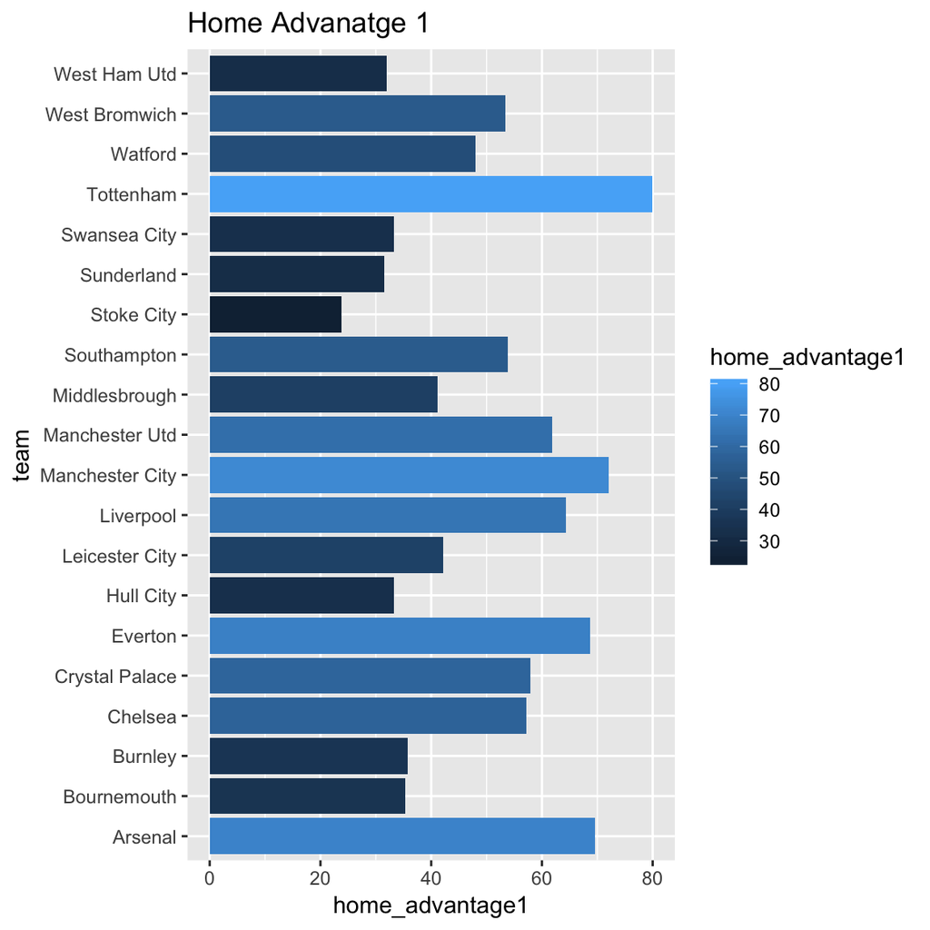

Tottenham scored the most points at home, Stoke city scored the least

Calculate the mean for the number of points scored by each team group using the aggregate function. There are total 20 teams.

```
              team home_advantage1
1          Arsenal        69.56522
2      Bournemouth        35.29412
3          Burnley        35.71429
4          Chelsea        57.14286
5   Crystal Palace        57.89474
6          Everton        68.75000
7        Hull City        33.33333
8   Leicester City        42.10526
9        Liverpool        64.28571
10 Manchester City        72.00000
11  Manchester Utd        61.90476
12   Middlesbrough        41.17647
13     Southampton        53.84615
14      Stoke City        23.80952
15      Sunderland        31.57895
16    Swansea City        33.33333
17       Tottenham        80.00000
18         Watford        48.00000
19   West Bromwich        53.33333
20    West Ham Utd        32.00000
```

By calculating overall mean, highest mean points are scored by Tottenham, and lowest meanpoints are scored by Stoke City.

Now we will summarize the dataset by grouping it by team and calculating the point_rate

```
# A tibble: 20 x 2
   team            `points_rate <- sum(home_advantage1)/sum(Total_goals)`
   <chr>                                                            <dbl>
 1 Arsenal                                                           3.02
 2 Bournemouth                                                       2.08
 3 Burnley                                                           2.55
 4 Chelsea                                                           2.72
 5 Crystal Palace                                                    3.05
 6 Everton                                                           4.30
 7 Hull City                                                         1.59
 8 Leicester City                                                    2.22
 9 Liverpool                                                         2.30
10 Manchester City                                                   2.88
11 Manchester Utd                                                    2.95
12 Middlesbrough                                                     2.42
13 Southampton                                                       4.14
14 Stoke City                                                        1.13
15 Sunderland                                                        1.66
16 Swansea City                                                      1.85
17 Tottenham                                                         5.33
18 Watford                                                           1.92
19 West Bromwich                                                     3.56
20 West Ham Utd                                                      1.28
```

```
# A tibble: 20 x 2
   team            `sum(home_advantage1)`
   <chr>                            <dbl>
 1 Arsenal                           69.6
 2 Bournemouth                       35.3
 3 Burnley                           35.7
 4 Chelsea                           57.1
 5 Crystal Palace                    57.9
 6 Everton                           68.8
 7 Hull City                         33.3
 8 Leicester City                    42.1
 9 Liverpool                         64.3
10 Manchester City                   72
11 Manchester Utd                    61.9
12 Middlesbrough                     41.2
13 Southampton                       53.8
14 Stoke City                        23.8
15 Sunderland                        31.6
16 Swansea City                      33.3
17 Tottenham                         80
18 Watford                           48
19 West Bromwich                     53.3
20 West Ham Utd                      32
```

By calculating overall point_rate, highest mean points are scored by Tottenham, and lowest meanpoints are scored by Stoke City.

To see which team scored the most GOALS at home

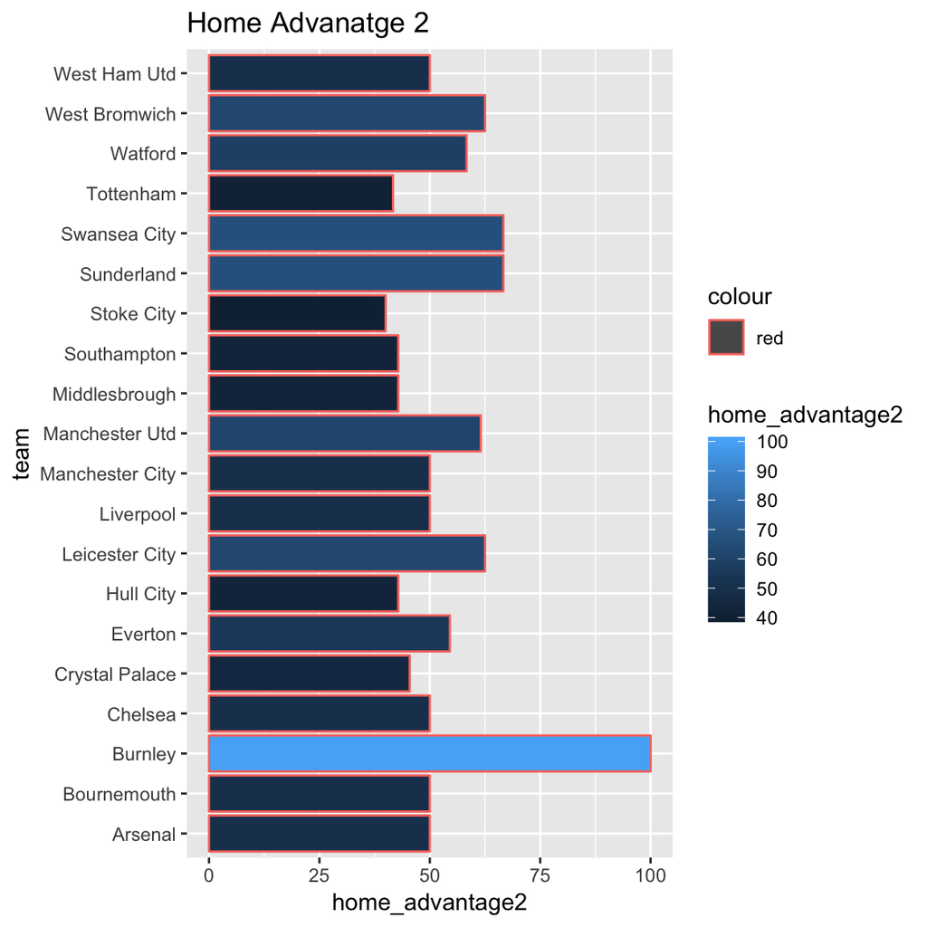

Burnley scored the most goals at home, Stoke city scored the least.

Now we will summarize the dataset by grouping it by team and calculating the goal_rate

```
# A tibble: 20 x 2
   team            `goal_rate <- sum(home_advantage2)/sum(Total_goals)`
   <chr>                                                          <dbl>
 1 Arsenal                                                         2.17
 2 Bournemouth                                                     2.94
 3 Burnley                                                         7.14
 4 Chelsea                                                         2.38
 5 Crystal Palace                                                  2.39
 6 Everton                                                         3.41
 7 Hull City                                                       2.04
 8 Leicester City                                                  3.29
 9 Liverpool                                                       1.79
10 Manchester City                                                 2
11 Manchester Utd                                                  2.93
12 Middlesbrough                                                   2.52
13 Southampton                                                     3.30
14 Stoke City                                                      1.90
15 Sunderland                                                      3.51
16 Swansea City                                                    3.70
17 Tottenham                                                       2.78
18 Watford                                                         2.33
19 West Bromwich                                                   4.17
20 West Ham Utd                                                    2
```

```
# A tibble: 20 x 2
   team            `sum(home_advantage2)`
   <chr>                            <dbl>
 1 Arsenal                           50
 2 Bournemouth                       50
 3 Burnley                          100
 4 Chelsea                           50
 5 Crystal Palace                    45.5
 6 Everton                           54.5
 7 Hull City                         42.9
 8 Leicester City                    62.5
 9 Liverpool                         50
10 Manchester City                   50
11 Manchester Utd                    61.5
12 Middlesbrough                     42.9
13 Southampton                       42.9
14 Stoke City                        40
15 Sunderland                        66.7
16 Swansea City                      66.7
17 Tottenham                         41.7
18 Watford                           58.3
19 West Bromwich                     62.5
20 West Ham Utd                      50
```

Calculate the mean for the number of goals scored by each team group using the aggregate function. There are total 20 teams

```
              team home_advantage2
1          Arsenal        50.00000
2      Bournemouth        50.00000
3          Burnley       100.00000
4          Chelsea        50.00000
5   Crystal Palace        45.45455
6          Everton        54.54545
7        Hull City        42.85714
8   Leicester City        62.50000
9        Liverpool        50.00000
10 Manchester City        50.00000
11  Manchester Utd        61.53846
12   Middlesbrough        42.85714
13     Southampton        42.85714
14      Stoke City        40.00000
15      Sunderland        66.66667
16    Swansea City        66.66667
17       Tottenham        41.66667
18         Watford        58.33333
19   West Bromwich        62.50000
20    West Ham Utd        50.00000
```

By calculating overall mean, highest mean goals are scored by Burnley, and lowest mean goals are scored by Stoke City.

## Conclusion

Tottenham scored the most points at home, Stoke city scored the least

Burnley scored the most goals at home, Stoke city scored the least.

# Dataset of Compairing monthly citizenship for a given region

## Create a dataframe and load the dataset from the .csv file

```
       Month REGION 1 REGION 2 REGION 3 REGION 4 REGION 5 TOTAL
1      April       13       33       76        2       47   171
2        May       17       55      209        1      143   425
3       June        8       63      221        1      127   420
4       July       13      104      240        6      123   486
5     August       18      121      274        9      111   533
6  September       25      160      239        2       88   514
7    October        9       88      295        2      127   521
8   November        2       86      292        2      120   502
9   December        1      128      232        6      155   522
10     TOTAL      106      838     2078       31     1041  4094
```

## Tidying and Transforming Data

Using the gather() to transform the data

To tidy the data, there are total 4 varibles in which we can tidy the dataset.

The four variables are: Month, region, month_total,Total

```
       Month   region month_total TOTAL
1      April REGION 1          13   171
2        May REGION 1          17   425
3       June REGION 1           8   420
4       July REGION 1          13   486
5     August REGION 1          18   533
6  September REGION 1          25   514
7    October REGION 1           9   521
8   November REGION 1           2   502
9   December REGION 1           1   522
10     TOTAL REGION 1         106  4094
11     April REGION 2          33   171
12       May REGION 2          55   425
13      June REGION 2          63   420
14      July REGION 2         104   486
15    August REGION 2         121   533
16 September REGION 2         160   514
17   October REGION 2          88   521
18  November REGION 2          86   502
 [ reached 'max' / getOption("max.print") -- omitted 32 rows ]
```

Summary of the tidy dataset

```
    Month              region           month_total         TOTAL
 Length:50          Length:50          Min.   :   1.0   Min.   : 171.0
 Class :character   Class :character   1st Qu.:  10.0   1st Qu.: 425.0
 Mode  :character   Mode  :character   Median :  87.0   Median : 508.0
                                       Mean   : 163.8   Mean   : 818.8
                                       3rd Qu.: 152.0   3rd Qu.: 522.0
                                       Max.   :2078.0   Max.   :4094.0
```

Now we have a tidy dataset, we’ll Compare monthly citizenship for the given regions by graphics

To see which region issues the most citizenships in the past 9 months

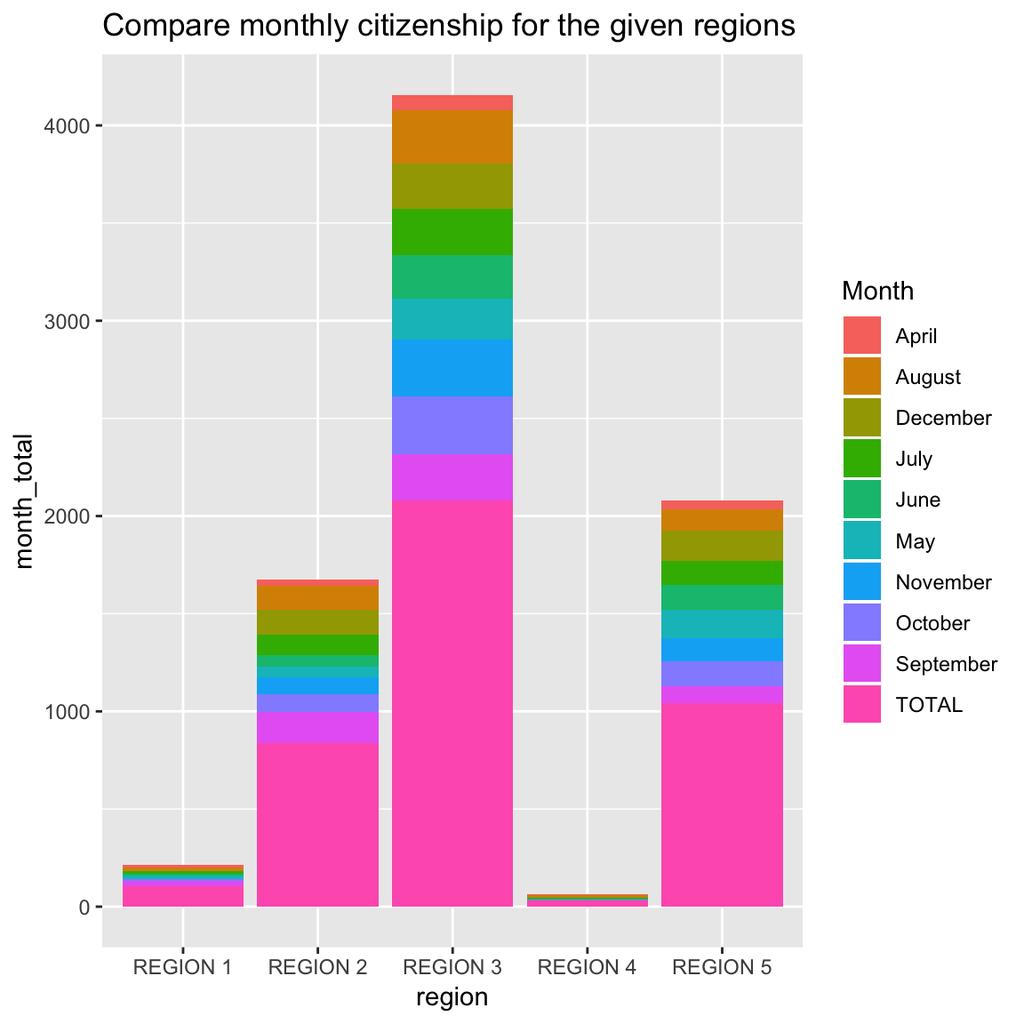

Region 3 issued the most citizenships over in the last 9 months and Region 4 issued the least.

Calculate the mean for the number of citizenships issued by each region using the aggregate function. There are total 5 teams.

```
    region month_total
1 REGION 1        21.2
2 REGION 2       167.6
3 REGION 3       415.6
4 REGION 4         6.2
5 REGION 5       208.2
```

Therefore, by calculating the overall mean by regions, we conclude that Region 3 issued most citizenships and Region 4 issued least

Now we will summarize the dataset by grouping it by region and calculating the rate in which the citizenship is being offered.

```
# A tibble: 5 x 2
  region   `citizenship_rate <- sum(month_total)/sum(TOTAL)`
  <chr>                                                <dbl>
1 REGION 1                                           0.0259
2 REGION 2                                           0.205
3 REGION 3                                           0.508
4 REGION 4                                           0.00757
5 REGION 5                                           0.254
```

```
# A tibble: 5 x 2
  region   `sum(month_total)`
  <chr>                 <int>
1 REGION 1                212
2 REGION 2               1676
3 REGION 3               4156
4 REGION 4                 62
5 REGION 5               2082
```

We will carry out a proportion test to know the statistical difference bewttn the Region 3 and Region 4

```
    2-sample test for equality of proportions with continuity
    correction

data:  c(4156, 62) out of c(8188, 8188)
X-squared = 5349.6, df = 1, p-value < 2.2e-16
alternative hypothesis: two.sided
95 percent confidence interval:
 0.4888875 0.5111125
sample estimates:
     prop 1      prop 2
0.507572057 0.007572057
```

We can see there is a significant statistical difference between region 3 and region 4 proportion.

We can also group the dataset by month to make it more specific.

```
      Month   region citizenship_rate
1     April REGION 1      0.076023392
2     April REGION 2      0.192982456
3     April REGION 3      0.444444444
4     April REGION 4      0.011695906
5     April REGION 5      0.274853801
6    August REGION 1      0.033771107
7    August REGION 2      0.227016886
8    August REGION 3      0.514071295
9    August REGION 4      0.016885553
10   August REGION 5      0.208255159
11 December REGION 1      0.001915709
12 December REGION 2      0.245210728
13 December REGION 3      0.444444444
14 December REGION 4      0.011494253
15 December REGION 5      0.296934866
16     July REGION 1      0.026748971
17     July REGION 2      0.213991770
18     July REGION 3      0.493827160
19     July REGION 4      0.012345679
20     July REGION 5      0.253086420
21     June REGION 1      0.019047619
22     June REGION 2      0.150000000
23     June REGION 3      0.526190476
24     June REGION 4      0.002380952
25     June REGION 5      0.302380952
 [ reached 'max' / getOption("max.print") -- omitted 25 rows ]
```

## Conclusion

By doing various analyses on the citizenship dataset, we conclude that:

Region 3 issued the most citizenships over in the last 9 months and Region 4 issued the least.